# 2021 Cálculo do IGC Ranking

# PROBLEMA

Calcular a posição do ranking da Universidade Federal do Triângulo Mineiro (UFTM) no IGC (O Índice Geral de Cursos é um dos instrumentos utilizados para conhecer o desempenho das instituições de ensino superior do Brasil. O instrumento é construído com base numa média ponderada das notas dos cursos de graduação e pós-graduação de cada instituição.)

# DATASET

https://www.gov.br/inep/pt-br/acesso-a-informacao/dados-abertos/indicadores-educacionais/indicadores-de-qualidade-da-educacao-superior

CARREGAR OS MÓDULOS

```r
library(readxl)
library(dplyr)
```

```r
library(ggplot2)
library(ggcorrplot)
```

CARREGAR O DATASET

```r
dados <- read_excel("IGC_2019.xlsx")
dados <- as.data.frame(dados)
```

VERIFICAR O NOME DAS COLUNAS DO DATASET

```r
colnames(dados)
```

```
##  [1] "Ano"
##  [2] "Código da IES"
##  [3] "Nome da IES"
##  [4] "Sigla da IES"
##  [5] "Organização Acadêmica"
##  [6] "Categoria Administrativa"
##  [7] "Sigla da UF"
##  [8] "Nº de Cursos com CPC no triênio"
##  [9] "Alfa (Proporção de Graduação)"
## [10] "Conceito Médio de Graduação"
## [11] "Beta (Proporção de Mestrado - Equivalente)"
## [12] "Conceito Médio de Mestrado"
## [13] "Gama (Proporção de Doutorandos – Equivalente)"
## [14] "Conceito Médio do doutorado"
## [15] "IGC (Contínuo)"
## [16] "IGC (Faixa)"
## [17] "TX_OBS"
```

VERIFICAR O NOME DAS LINHAS

```r
rownames(dados)[1:20]
```

```
##  [1] "1"  "2"  "3"  "4"  "5"  "6"  "7"  "8"  "9"  "10" "11" "12" "13" "14" "15"
## [16] "16" "17" "18" "19" "20"
```

VERIFICAR O TAMANHA DO DATASET

```r
dim(dados)
```

```
## [1] 2090   17
```

VERIFICAR OS TIPOS DE DADOS DO DATASET

```r
str(dados)
```

```
## 'data.frame':    2090 obs. of  17 variables:
##  $ Ano                                          : num  2019 2019 2019 2019 2019 ...
##  $ Código da IES                                : num  1 2 3 4 5 6 7 8 9 10 ...
##  $ Nome da IES                                  : chr  "UNIVERSIDADE FEDERAL DE MATO GROSSO" "UNIVERSIDADE DE BRASÍLIA" "UNIVERSIDADE FEDERAL DE SERGIPE" "UNIVERSIDADE FEDERAL DO AMAZONAS" ...
##  $ Sigla da IES                                 : chr  "UFMT" "UNB" "UFS" "UFAM" ...
##  $ Organização Acadêmica                        : chr  "Universidade" "Universidade" "Universidade" "Universidade" ...
##  $ Categoria Administrativa                     : chr  "Pública Federal" "Pública Federal" "Pública Federal" "Pública Federal" ...
##  $ Sigla da UF                                  : chr  "MT" "DF" "SE" "AM" ...
##  $ Nº de Cursos com CPC no triênio              : num  91 87 90 75 77 44 58 63 47 70 ...
##  $ Alfa (Proporção de Graduação)                : chr  "0.79335476959999995" "0.52436395869999997" "0.80141717700000004" "0.84858188469999996" ...
##  $ Conceito Médio de Graduação                  : chr  "2.9249620906999998" "3.2695857893000002" "3.1054996969999999" "2.8218514477999999" ...
##  $ Beta (Proporção de Mestrado - Equivalente)   : chr  "0.13380493030000001" "0.23254033800000001" "0.1218487395" "0.1029658432" ...
##  $ Conceito Médio de Mestrado                   : chr  "4.2998462327000002" "4.5884405054000004" "4.2752605347000001" "4.2343665035000004" ...
##  $ Gama (Proporção de Doutorandos – Equivalente): chr  "7.2840300100000005E-2" "0.24309570329999999" "7.6734083499999994E-2" "4.8452271999999998E-2" ...
##  $ Conceito Médio do doutorado                  : chr  "4.6765927977999997" "4.7726399230999998" "4.6636069113999996" "4.4914196567999998" ...
##  $ IGC (Contínuo)                               : num  3.24 3.94 3.37 3.05 2.96 ...
##  $ IGC (Faixa)                                  : chr  "4" "4" "4" "4" ...
##  $ TX_OBS                                       : logi  NA NA NA NA NA NA ...
```

VERIFICAR OS TIPOS DE DADOS DO DATASET

```r
glimpse(dados)
```

```
## Rows: 2,090
## Columns: 17
## $ Ano                                             <dbl> 2019, 2019, 2019, 2019~
## $ `Código da IES`                                 <dbl> 1, 2, 3, 4, 5, 6, 7, 8~
## $ `Nome da IES`                                   <chr> "UNIVERSIDADE FEDERAL ~
## $ `Sigla da IES`                                  <chr> "UFMT", "UNB", "UFS", ~
## $ `Organização Acadêmica`                         <chr> "Universidade", "Unive~
## $ `Categoria Administrativa`                      <chr> "Pública Federal", "Pú~
## $ `Sigla da UF`                                   <chr> "MT", "DF", "SE", "AM"~
## $ `Nº de Cursos com CPC no triênio`               <dbl> 91, 87, 90, 75, 77, 44~
## $ `Alfa (Proporção de Graduação)`                 <chr> "0.79335476959999995",~
## $ `Conceito Médio de Graduação`                   <chr> "2.9249620906999998", ~
## $ `Beta (Proporção de Mestrado - Equivalente)`    <chr> "0.13380493030000001",~
## $ `Conceito Médio de Mestrado`                    <chr> "4.2998462327000002", ~
## $ `Gama (Proporção de Doutorandos – Equivalente)` <chr> "7.2840300100000005E-2~
## $ `Conceito Médio do doutorado`                   <chr> "4.6765927977999997", ~
## $ `IGC (Contínuo)`                                <dbl> 3.236518, 3.941659, 3.~
## $ `IGC (Faixa)`                                   <chr> "4", "4", "4", "4", "4~
## $ TX_OBS                                          <lgl> NA, NA, NA, NA, NA, NA~
```

VERIFICAR A QUANTIDADE DE VALORES ÚNICOS

```r
sapply(dados, function(x) length(unique(x)))
```

```
##                                           Ano
##                                             1
##                                 Código da IES
##                                          2090
##                                   Nome da IES
##                                          2070
##                                  Sigla da IES
##                                          1549
##                         Organização Acadêmica
##                                             5
##                      Categoria Administrativa
##                                             6
##                                   Sigla da UF
##                                            27
##               Nº de Cursos com CPC no triênio
##                                           103
##                 Alfa (Proporção de Graduação)
##                                           337
##                   Conceito Médio de Graduação
##                                          2071
##    Beta (Proporção de Mestrado - Equivalente)
##                                           335
##                    Conceito Médio de Mestrado
##                                           222
## Gama (Proporção de Doutorandos – Equivalente)
##                                           211
##                   Conceito Médio do doutorado
##                                           123
##                                IGC (Contínuo)
##                                          2071
##                                   IGC (Faixa)
##                                             6
##                                        TX_OBS
##                                             1
```

VERIFICAR O RESUMO DO DATASET

```r
summary(dados)
```

```
##       Ano       Código da IES   Nome da IES        Sigla da IES
##  Min.   :2019   Min.   :    1   Length:2090        Length:2090
##  1st Qu.:2019   1st Qu.: 1144   Class :character   Class :character
##  Median :2019   Median : 2044   Mode  :character   Mode  :character
##  Mean   :2019   Mean   : 3994
##  3rd Qu.:2019   3rd Qu.: 4106
##  Max.   :2019   Max.   :23410
##
##  Organização Acadêmica Categoria Administrativa Sigla da UF
##  Length:2090           Length:2090              Length:2090
##  Class :character      Class :character         Class :character
##  Mode  :character      Mode  :character         Mode  :character
##
##
##
##
##  Nº de Cursos com CPC no triênio Alfa (Proporção de Graduação)
##  Min.   :  0.00                  Length:2090
##  1st Qu.:  2.00                  Class :character
##  Median :  5.00                  Mode  :character
##  Mean   : 11.55
##  3rd Qu.: 11.00
##  Max.   :713.00
##
##  Conceito Médio de Graduação Beta (Proporção de Mestrado - Equivalente)
##  Length:2090                 Length:2090
##  Class :character            Class :character
##  Mode  :character            Mode  :character
##
##
##
##
##  Conceito Médio de Mestrado Gama (Proporção de Doutorandos – Equivalente)
##  Length:2090                Length:2090
##  Class :character           Class :character
##  Mode  :character           Mode  :character
##
##
##
##
##  Conceito Médio do doutorado IGC (Contínuo)   IGC (Faixa)         TX_OBS
##  Length:2090                 Min.   :0.7498   Length:2090        Mode:logical
##  Class :character            1st Qu.:2.2099   Class :character   NA's:2090
##  Mode  :character            Median :2.5493   Mode  :character
##                              Mean   :2.5765
##                              3rd Qu.:2.9228
##                              Max.   :4.8549
##                              NA's   :20
```

VERIFICAR A QUANTIDADE DE VALORES MISSING

```r
sapply(dados, function(x) sum(is.na(x)))
```

```
##                                           Ano
##                                             0
##                                 Código da IES
##                                             0
##                                   Nome da IES
##                                             0
##                                  Sigla da IES
##                                           316
##                         Organização Acadêmica
##                                             0
##                      Categoria Administrativa
##                                             0
##                                   Sigla da UF
##                                             0
##               Nº de Cursos com CPC no triênio
##                                             0
##                 Alfa (Proporção de Graduação)
##                                             0
##                   Conceito Médio de Graduação
##                                             0
##    Beta (Proporção de Mestrado - Equivalente)
##                                             0
##                    Conceito Médio de Mestrado
##                                             0
## Gama (Proporção de Doutorandos – Equivalente)
##                                             0
##                   Conceito Médio do doutorado
##                                             0
##                                IGC (Contínuo)
##                                            20
##                                   IGC (Faixa)
##                                             0
##                                        TX_OBS
##                                          2090
```

VERIFICAR A QUANTIDADE DE VALORES NULOS

```r
sapply(dados, function(x) sum(is.null(x)))
```

```
##                                           Ano
##                                             0
##                                 Código da IES
##                                             0
##                                   Nome da IES
##                                             0
##                                  Sigla da IES
##                                             0
##                         Organização Acadêmica
##                                             0
##                      Categoria Administrativa
##                                             0
##                                   Sigla da UF
##                                             0
##               Nº de Cursos com CPC no triênio
##                                             0
##                 Alfa (Proporção de Graduação)
##                                             0
##                   Conceito Médio de Graduação
##                                             0
##    Beta (Proporção de Mestrado - Equivalente)
##                                             0
##                    Conceito Médio de Mestrado
##                                             0
## Gama (Proporção de Doutorandos – Equivalente)
##                                             0
##                   Conceito Médio do doutorado
##                                             0
##                                IGC (Contínuo)
##                                             0
##                                   IGC (Faixa)
##                                             0
##                                        TX_OBS
##                                             0
```

VERIFICAR AS PRIMEIRAS LINHAS DO DATASET

```r
head(dados, 5)
```

```
##    Ano Código da IES                         Nome da IES Sigla da IES
## 1 2019             1 UNIVERSIDADE FEDERAL DE MATO GROSSO         UFMT
## 2 2019             2            UNIVERSIDADE DE BRASÍLIA          UNB
## 3 2019             3     UNIVERSIDADE FEDERAL DE SERGIPE          UFS
## 4 2019             4    UNIVERSIDADE FEDERAL DO AMAZONAS         UFAM
## 5 2019             5       UNIVERSIDADE FEDERAL DO PIAUÍ         UFPI
##   Organização Acadêmica Categoria Administrativa Sigla da UF
## 1          Universidade          Pública Federal          MT
## 2          Universidade          Pública Federal          DF
## 3          Universidade          Pública Federal          SE
## 4          Universidade          Pública Federal          AM
## 5          Universidade          Pública Federal          PI
##   Nº de Cursos com CPC no triênio Alfa (Proporção de Graduação)
## 1                              91           0.79335476959999995
## 2                              87           0.52436395869999997
```

[output cut: 21 more lines]

VERIFICAR AS ÚLTIMAS LINHAS DO DATASET

```r
tail(dados)
```

```
##       Ano Código da IES                                           Nome da IES
## 2085 2019         19861                      Faculdade de Santana de Parnaíba
## 2086 2019         19862            Faculdade de Tecnologia Jorge Caram Sabbag
## 2087 2019         19863                      Faculdade de Tecnologia de Assis
## 2088 2019         20478        Faculdade de Tecnologia de Santana de Parnaíba
## 2089 2019         22015       Faculdade Municipal de Educação e Meio Ambiente
## 2090 2019         23410 UNIVERSIDADE ESTADUAL DA REGIÃO TOCANTINA DO MARANHÃO
##         Sigla da IES Organização Acadêmica    Categoria Administrativa
## 2085            FASP             Faculdade Privada sem fins lucrativos
## 2086 FATEC Bebedouro             Faculdade            Pública Estadual
## 2087     FATEC Assis             Faculdade            Pública Estadual
## 2088       FATEC-SPB             Faculdade            Pública Estadual
## 2089            FAMA             Faculdade           Pública Municipal
## 2090         UEMASUL          Universidade            Pública Estadual
##      Sigla da UF Nº de Cursos com CPC no triênio Alfa (Proporção de Graduação)
```

[output cut: 27 more lines]

VERIFIAR VALORES ALEATÓRIOS DO DATASET

```r
sample_n(dados, 5)
```

```
##    Ano Código da IES                             Nome da IES Sigla da IES
## 1 2019           269                        FACULDADE FACCAT       FACCAT
## 2 2019          2908 FACULDADE NATALENSE DE ENSINO E CULTURA        FANEC
## 3 2019           873  FACULDADES UNIFICADAS DE FOZ DO IGUAÇU       UNIFOZ
## 4 2019          2036 Faculdade Estácio do Pará - Estácio FAP  ESTÁCIO FAP
## 5 2019          2754                     FACULDADE SÃO PAULO          FSP
##   Organização Acadêmica    Categoria Administrativa Sigla da UF
## 1             Faculdade Privada com fins lucrativos          SP
## 2  Centro Universitário Privada com fins lucrativos          RN
## 3             Faculdade Privada com fins lucrativos          PR
## 4             Faculdade Privada com fins lucrativos          PA
## 5             Faculdade Privada com fins lucrativos          RO
##   Nº de Cursos com CPC no triênio Alfa (Proporção de Graduação)
## 1                               8                             1
## 2                               7                             1
```

[output cut: 21 more lines]

VERIFICAR A QUANTIDADE DE VALORES MISSING DA VARIÁVEL

```r
dim(dados[is.na(dados$`IGC (Contínuo)`), ])
```

```
## [1] 20 17
```

VERIFICAR OS REGISTROS QUE TEM VALORES MISSING

```r
dados[is.na(dados$`IGC (Contínuo)`), ]
```

```
##       Ano Código da IES                                            Nome da IES
## 322  2019           651     FACULDADE DE ADMINISTRAÇÃO DE GOVERNADOR VALADARES
## 353  2019           708                INSTITUTO DE CIÊNCIAS SOCIAIS APLICADAS
## 466  2019          1034                  UNIÃO DE ESCOLAS SUPERIORES DA FUNESO
## 489  2019          1072                                   FACULDADE AFIRMATIVO
## 717  2019          1501                 FACULDADE LATINO AMERICANA DE EDUCAÇÃO
## 797  2019          1628                 FACULDADE DE CIÊNCIAS HUMANAS DE AGUAÍ
## 950  2019          1865                            Faculdade Alvorada Paulista
## 1052 2019          2075                INSTITUTO DE ENSINO SUPERIOR DE ALAGOAS
## 1215 2019          2566                 INSTITUTO DE ENSINO SUPERIOR DE OLINDA
## 1305 2019          2927                            FACULDADE DE BELO HORIZONTE
## 1367 2019          3307                                 FACULDADE DE RIO CLARO
## 1562 2019          4095 FACULDADE DE TECNOLOGIA E CIÊNCIAS DO DISTRITO FEDERAL
## 1645 2019          4605                         FACULDADE DE CORNÉLIO PROCÓPIO
## 1668 2019          4739                 FACULDADE PRESBITERIANA AUGUSTO GALVÃO
```

[output cut: 111 more lines]

EXCLUIR OS REGISTROS COM VALORES MISSING

```r
dados <- dados[!is.na(dados$`IGC (Contínuo)`), ]
```

PLOTAR HISTROGRAMA

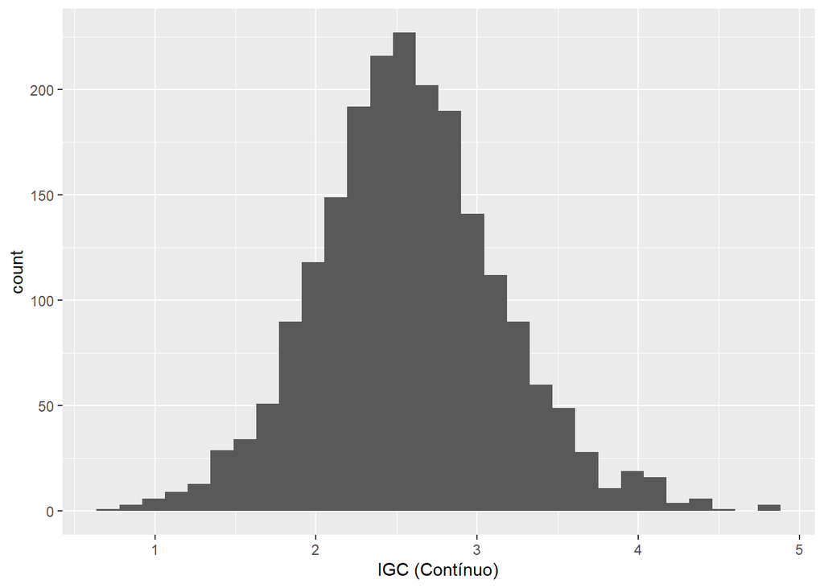

```r
ggplot(dados) +
  aes(x = `IGC (Contínuo)`) +
  geom_histogram()
```

PLOTAR BOXPLOT

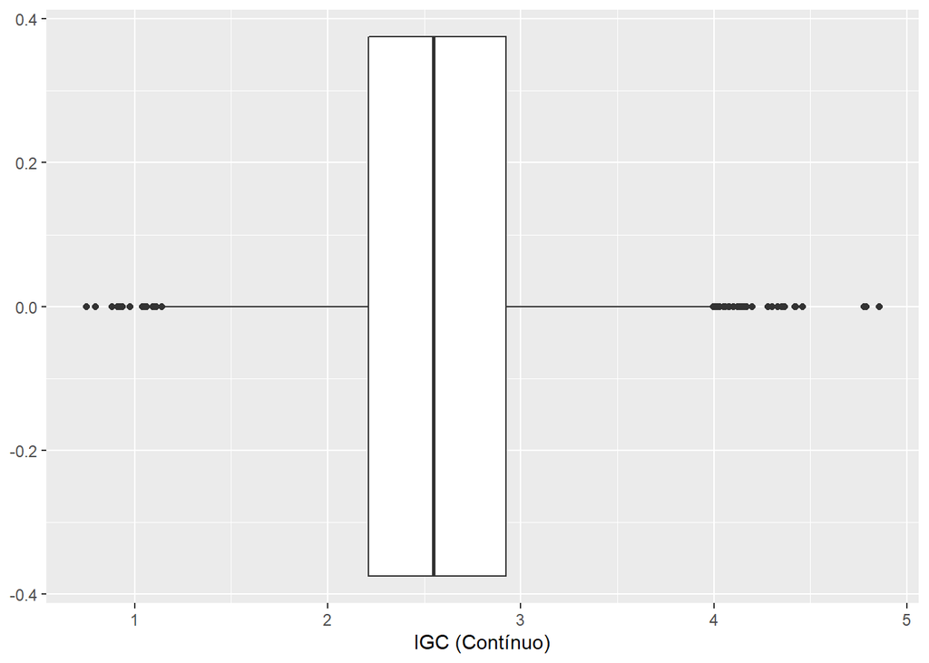

```r
ggplot(dados) +
  aes(x = `IGC (Contínuo)`) +
  geom_boxplot()
```

VERIFICAR A MÉDIA POR UF

```r
filtro <- dados %>%
  group_by(`Sigla da UF`) %>%
  summarise( media = mean(`IGC (Contínuo)`)) %>%
  arrange(media)
levels <- filtro$`Sigla da UF`
filtro$`Sigla da UF` <- factor(filtro$`Sigla da UF`, levels=levels, ordered=TRUE)
filtro
```

```
## # A tibble: 27 x 2
##    `Sigla da UF` media
##    <ord>         <dbl>
##  1 AL             2.21
##  2 AP             2.22
##  3 TO             2.32
##  4 PI             2.39
##  5 MS             2.39
##  6 MT             2.40
##  7 PE             2.41
##  8 PA             2.47
##  9 MA             2.49
## 10 AM             2.49
## # ... with 17 more rows
```

PLOTAR A MÉDIA POR UF

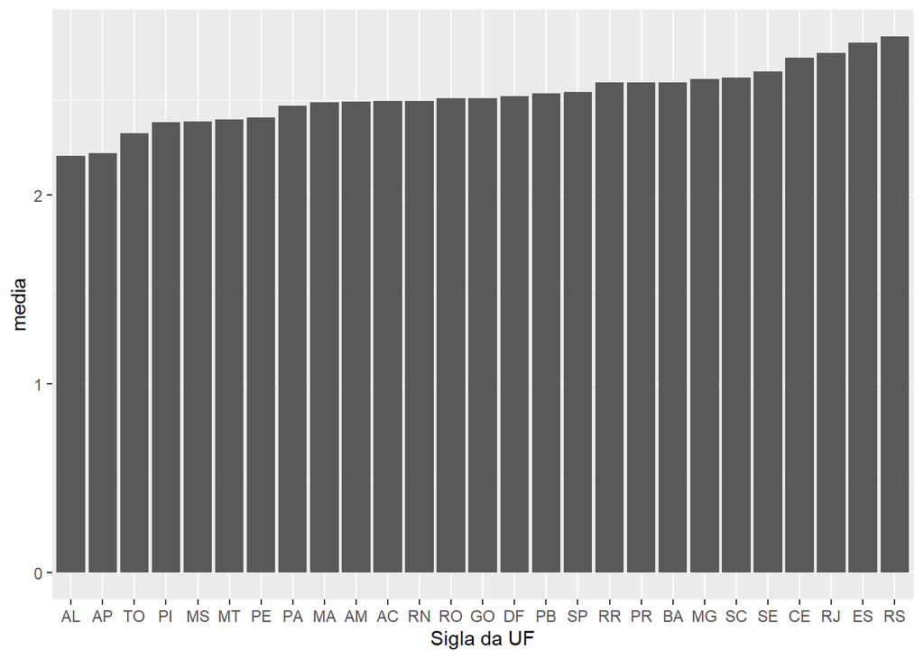

```r
filtro %>%
  ggplot(aes(x = `Sigla da UF`, y = media)) +
  geom_col()
```

PLOTAR O BOXPLOT POR UF

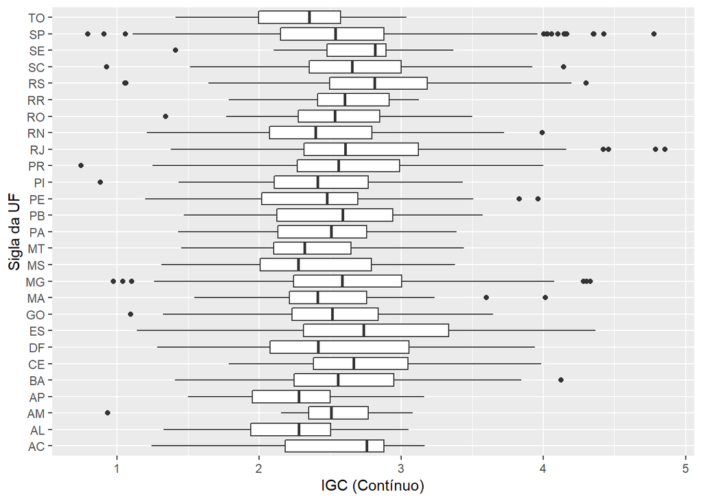

```r
ggplot(dados, aes(x = `IGC (Contínuo)`, y = `Sigla da UF`)) +
  geom_boxplot()
```

VERIFICAR A MÉDIA POR CATEGORIA ADM

```r
filtro <- dados %>%
  group_by(`Categoria Administrativa`) %>%
  summarise( media = mean(`IGC (Contínuo)`)) %>%
  arrange(media)
levels <- filtro$`Categoria Administrativa`
filtro$`Categoria Administrativa` <- factor(filtro$`Categoria Administrativa`,
                                            levels=levels, ordered=TRUE)
filtro
```

```
## # A tibble: 6 x 2
##   `Categoria Administrativa`  media
##   <ord>                       <dbl>
## 1 Especial                     2.21
## 2 Pública Municipal            2.33
## 3 Privada com fins lucrativos  2.48
## 4 Privada sem fins lucrativos  2.60
## 5 Pública Estadual             2.79
## 6 Pública Federal              3.28
```

PLOTAR A MÉDIA POR CATEGORIA ADM

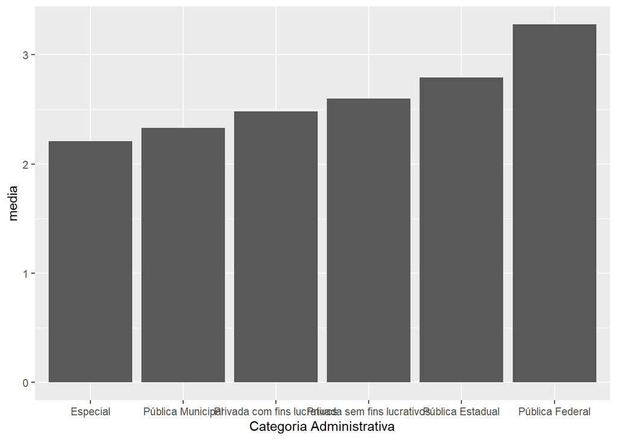

```r
filtro %>%
  ggplot(aes(x = `Categoria Administrativa`, y = media)) +
  geom_col()
```

PLOTAR O BOXPLOT POR CATEGORIA ADM

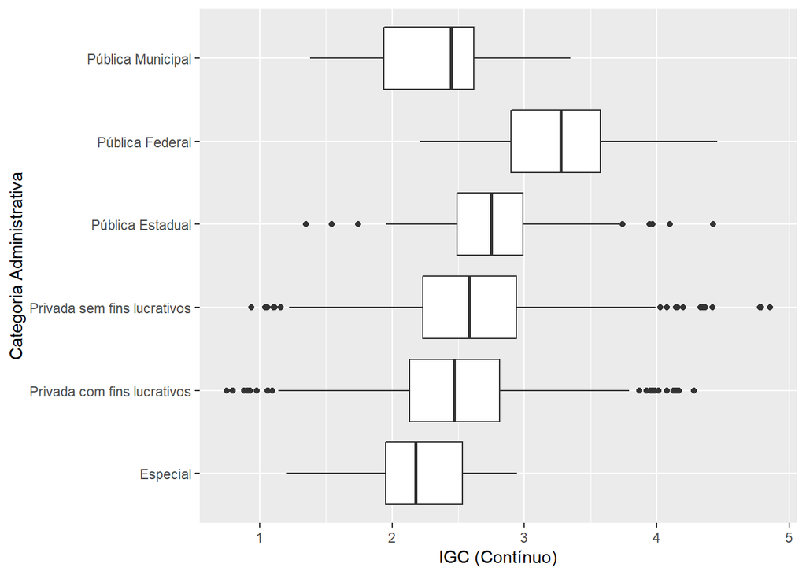

```r
ggplot(dados, aes(x = `IGC (Contínuo)`, y = `Categoria Administrativa`)) +
  geom_boxplot()
```

VERIFICAR A MÉDIA POR ORGANIZAÇÃO ACADÊMICA

```r
filtro <- dados %>%
  group_by(`Organização Acadêmica`) %>%
  summarise( media = mean(`IGC (Contínuo)`)) %>%
  arrange(media)
levels <- filtro$`Organização Acadêmica`
filtro$`Organização Acadêmica` <- factor(filtro$`Organização Acadêmica`,
                                            levels=levels, ordered=TRUE)
filtro
```

```
## # A tibble: 5 x 2
##   `Organização Acadêmica`                             media
##   <ord>                                               <dbl>
## 1 Faculdade                                            2.45
## 2 Centro Universitário                                 2.82
## 3 Instituto Federal de Educação, Ciência e Tecnologia  2.83
## 4 Universidade                                         3.11
## 5 Centro Federal de Educação Tecnológica               3.51
```

PLOTAR A MÉDIA POR ORGANIZAÇÃO ACADÊMICA

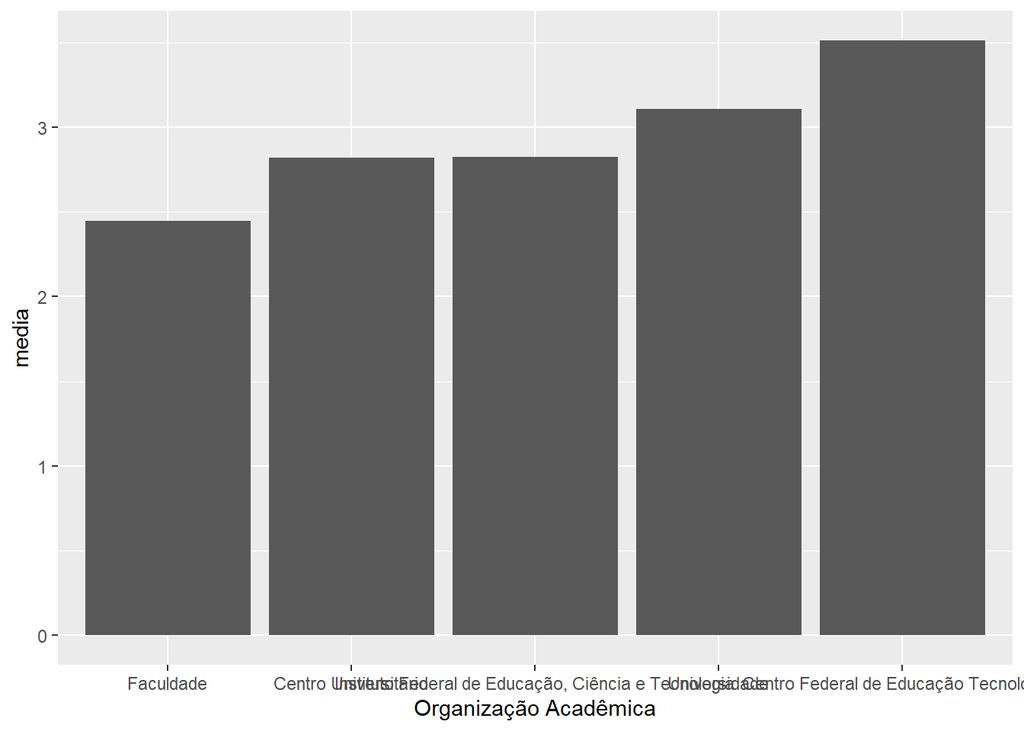

```r
filtro %>%
  ggplot(aes(x = `Organização Acadêmica`, y = media)) +
  geom_col()
```

PLOTAR O BOXPLOT POR ORGANIZAÇÃO ACADÊMICA

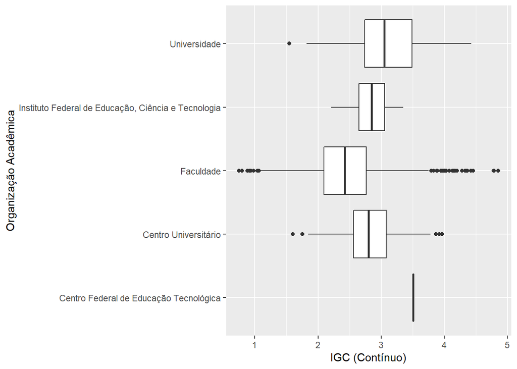

```r
ggplot(dados, aes(x = `IGC (Contínuo)`, y = `Organização Acadêmica`)) +
  geom_boxplot()
```

PLOTAR A QUANTIDADE DE ORGANIZAÇÃO ACADÊMICA

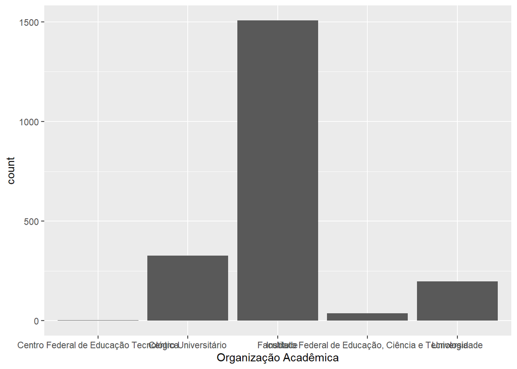

```r
ggplot(dados, aes(x = `Organização Acadêmica`)) +
  geom_bar()
```

CONVERTER AS VARIÁVEIS DE TEXTO PARA NUMÉRICO

```r
colunas <- c("Nº de Cursos com CPC no triênio",
"Alfa (Proporção de Graduação)",
"Conceito Médio de Graduação",
"Beta (Proporção de Mestrado - Equivalente)",
"Conceito Médio de Mestrado",
"Gama (Proporção de Doutorandos – Equivalente)",
"Conceito Médio do doutorado",
"IGC (Contínuo)",
"IGC (Faixa)" )
for (cl in colunas){
  dados[cl] <- as.double(dados[, cl])
}
cor(dados[, colunas])
```

```
##                                               Nº de Cursos com CPC no triênio
## Nº de Cursos com CPC no triênio                                     1.0000000
## Alfa (Proporção de Graduação)                                      -0.2681261
## Conceito Médio de Graduação                                         0.1902578
## Beta (Proporção de Mestrado - Equivalente)                          0.2203062
## Conceito Médio de Mestrado                                          0.5139914
## Gama (Proporção de Doutorandos – Equivalente)                       0.2966543
## Conceito Médio do doutorado                                         0.5488676
## IGC (Contínuo)                                                      0.2431461
## IGC (Faixa)                                                         0.2066042
##                                               Alfa (Proporção de Graduação)
## Nº de Cursos com CPC no triênio                                  -0.2681261
## Alfa (Proporção de Graduação)                                     1.0000000
## Conceito Médio de Graduação                                      -0.3197487
## Beta (Proporção de Mestrado - Equivalente)                       -0.9579571
## Conceito Médio de Mestrado                                       -0.6291543
## Gama (Proporção de Doutorandos – Equivalente)                    -0.8872498
## Conceito Médio do doutorado                                      -0.6571712
## IGC (Contínuo)                                                   -0.4999578
## IGC (Faixa)                                                      -0.4550394
##                                               Conceito Médio de Graduação
## Nº de Cursos com CPC no triênio                                 0.1902578
## Alfa (Proporção de Graduação)                                  -0.3197487
## Conceito Médio de Graduação                                     1.0000000
## Beta (Proporção de Mestrado - Equivalente)                      0.3217862
## Conceito Médio de Mestrado                                      0.3264436
## Gama (Proporção de Doutorandos – Equivalente)                   0.2588074
## Conceito Médio do doutorado                                     0.2710030
## IGC (Contínuo)                                                  0.9768458
## IGC (Faixa)                                                     0.8772144
##                                               Beta (Proporção de Mestrado - Equivalente)
## Nº de Cursos com CPC no triênio                                                0.2203062
## Alfa (Proporção de Graduação)                                                 -0.9579571
## Conceito Médio de Graduação                                                    0.3217862
## Beta (Proporção de Mestrado - Equivalente)                                     1.0000000
## Conceito Médio de Mestrado                                                     0.6325637
## Gama (Proporção de Doutorandos – Equivalente)                                  0.7175979
## Conceito Médio do doutorado                                                    0.5922731
## IGC (Contínuo)                                                                 0.4827892
## IGC (Faixa)                                                                    0.4391130
```

[output cut: 25 more lines]

```
## Conceito Médio de Mestrado                                      0.7863032
## Gama (Proporção de Doutorandos – Equivalente)                   0.6429946
## Conceito Médio do doutorado                                     1.0000000
## IGC (Contínuo)                                                  0.4001815
## IGC (Faixa)                                                     0.3673795
##                                               IGC (Contínuo) IGC (Faixa)
## Nº de Cursos com CPC no triênio                    0.2431461   0.2066042
## Alfa (Proporção de Graduação)                     -0.4999578  -0.4550394
## Conceito Médio de Graduação                        0.9768458   0.8772144
## Beta (Proporção de Mestrado - Equivalente)         0.4827892   0.4391130
## Conceito Médio de Mestrado                         0.4385876   0.3907532
## Gama (Proporção de Doutorandos – Equivalente)      0.4373959   0.3985810
## Conceito Médio do doutorado                        0.4001815   0.3673795
## IGC (Contínuo)                                     1.0000000   0.8974351
## IGC (Faixa)                                        0.8974351   1.0000000
```

PLOTAR AS CORRELAÇÕES

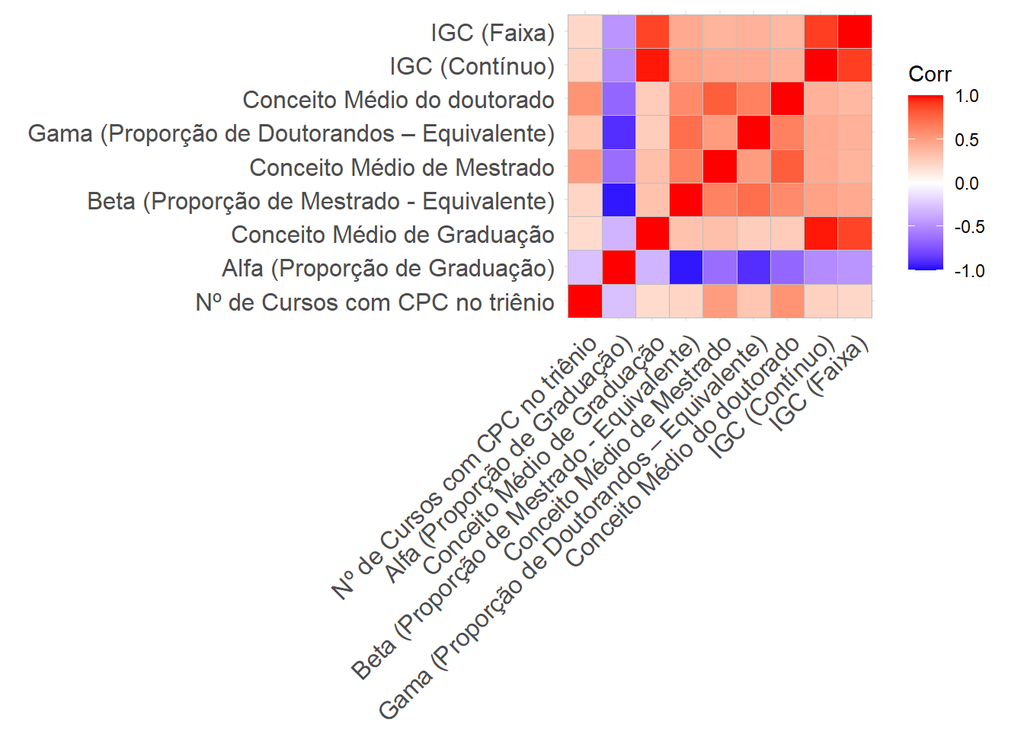

```r
ggcorrplot(cor(dados[, colunas]))
```

CRIAR A FUNÇÃO PARA CRIAR O RANKING

```r
ranking <- function(dados, coluna, parametros){
  "FUNÇÃO PARA CRIAR O RANKING
  ENTRA
    DATASET, COLUNA E OS PARAMETROS PARA FILTRO
  SAI
    A MEDIA, NOTA E O RANKING"

  filtro <- dados[dados[, coluna] %in% parametros, ]
  filtro <- filtro %>% arrange(desc(`IGC (Contínuo)` ))

  media <- mean(filtro$`IGC (Contínuo)`)
  linha <- which(filtro$`Código da IES` == 597)
  nota <- filtro[linha, 'IGC (Contínuo)']

  return(c(media, nota, linha))
}
```

CRIAR O RANKING POR CATEGORIA

```r
v1 <- ranking(dados,'Categoria Administrativa', c('Pública Federal') )
v2 <- ranking(dados,'Categoria Administrativa', c('Pública Federal', 'Pública Estadual', 'Pública Municipal') )
resultado <- data.frame(rbind(v1, v2))
colnames(resultado) <- c('Média', 'Nota', 'Posição')
rownames(resultado) <- c('Pública Federal', 'Públicas')
resultado
```

```
##                    Média     Nota Posição
## Pública Federal 3.277800 3.549261      30
## Públicas        2.940034 3.549261      41
```

CRIAR O RANKING POR UF E CATEGORIA ADMINISTRATIVA

```r
ddf = dados[which(dados$`Categoria Administrativa` == 'Pública Federal'),]
v1 <- ranking(ddf,'Sigla da UF', c('MG') )
v2 <- ranking(ddf,'Sigla da UF', c('MG', 'SP', 'RJ', 'ES') )
v3 <- ranking(ddf,'Sigla da UF', c(unique(ddf$`Sigla da UF`)) )
resultado <- data.frame(rbind(v1, v2, v3))
colnames(resultado) <- c('Média', 'Nota', 'Posição')
rownames(resultado) <- c('Estadual', 'Região', 'Brasil')
resultado
```

```
##             Média     Nota Posição
## Estadual 3.450510 3.549261       6
## Região   3.528051 3.549261      15
## Brasil   3.277800 3.549261      30
```

CRIAR O RANKING POR UF

```r
v1 <- ranking(dados,'Sigla da UF', c('MG') )
v2 <- ranking(dados,'Sigla da UF', c('MG', 'SP', 'RJ', 'ES') )
v3 <- ranking(dados,'Sigla da UF', c(unique(dados$`Sigla da UF`)) )
resultado <- data.frame(rbind(v1, v2, v3))
colnames(resultado) <- c('Média', 'Nota', 'Posição')
rownames(resultado) <- c('Estadual', 'Região', 'Brasil')
resultado
```

```
##             Média     Nota Posição
## Estadual 2.614208 3.549261      10
## Região   2.607671 3.549261      65
## Brasil   2.576483 3.549261     112
```